# Transferring 2013 Analysis to R

Sean Davern

June 5, 2019

# Objective of this Work

The objective of the work captured in this notebook is to translate part of an analysis done in 2013 (See Davern (2013)) into R to learn and demonstrate multiple R capabilities and workflows.

# Import of Data

The original data was provided by John Earling in a work book entitled ‘Weekly PayPay & Tithes .xls’ workbook. The layout/format of that workbook was not conducive to easily loading into R [nor JMP originally] and so was transcribed into the workbook ‘Giving Data.xlsx’ and then read into R.

```r
source("../code/0-Extract data from Excel.R")
df  # This is the data frame resulting from the import.
```

| week.ending | month | year | paypal | offering | total | monthly.giving.families |
| --- | --- | --- | --- | --- | --- | --- |
| 2010-01-03 | January | 2010 | 75.00 | 1560.00 | 1635.00 | NA |
| 2010-01-10 | January | 2010 | 575.00 | 3129.00 | 3704.00 | NA |
| 2010-01-17 | January | 2010 | 475.00 | 2025.00 | 2500.00 | NA |
| 2010-01-24 | January | 2010 | 75.00 | 1180.05 | 1255.05 | NA |
| 2010-01-31 | January | 2010 | 2180.00 | 2967.10 | 5147.10 | 45 |
| 2010-02-07 | February | 2010 | 75.00 | 4722.50 | 4797.50 | NA |
| 2010-02-14 | February | 2010 | 585.00 | 2925.00 | 3510.00 | NA |
| 2010-02-21 | February | 2010 | 200.00 | 3299.00 | 3499.00 | NA |
| 2010-02-28 | February | 2010 | 6350.00 | 4281.00 | 10631.00 | 41 |
| 2010-03-07 | March | 2010 | 770.00 | 1170.00 | 1940.00 | NA |

[output cut: 459 more lines]

# Some Minor Data Validation

As a first validation I’ll check that the weekly PayPal and offering amounts sum to the weekly totals $(paypal_i+{offering}_i\overset{?}=total_i)$, reporting only those that aren’t equal:

```r
source("../code/1-Validate totals.R")
```

```
***** WARNING *****
Some 'total' observations don't equal the sum of 'paypal' and 'offering'!
```

| week.ending | month | year | paypal | offering | total | calcd.total | diff |
| --- | --- | --- | --- | --- | --- | --- | --- |
| 2015-12-27 | December | 2015 | 1902 | 9306 | 16958 | 11208 | 5750 |
| 2016-12-25 | December | 2016 | 4635 | 10089 | 22849 | 14724 | 8125 |
| 2017-04-23 | April | 2017 | 635 | 4480 | 4615 | 5115 | -500 |

Ok, so December 2015 and 2016 seem to have totals greater than accounted for by the PayPal and offering amounts. That’s perhaps explainable by other end-of-year giving coming in another way. However, the April 2017 discrepancy seems to be missing $500. I’ll need to look into that.

# Data Transformation

Aggregating the monthly totals and preparing to model month values…

```r
# Data transformation: Calculate monthly giving totals.
# Make Month a categorical variable with levels in the order that
# months occur in the year otherwise months are sorted alphabetically.
df$month <- factor(df$month, month.name)
# Aggregate the monthly Totals from giving.data in sums for each month.
MonthTotals <-
  aggregate(df$total, by = list(df$month, df$year), FUN = sum)
# Exclude the months that don't have totals yet.
MonthTotals <- MonthTotals[complete.cases(MonthTotals), ]
# Extract only rows containing 'monthly.giving.families' data.
df <- df[!is.na(df$monthly.giving.families),]
# Now replace Totals (which were weekly totals) with calculated aggregates
df$total <- MonthTotals$x
# paypal & offering columns are now misleading (only week's value) so remove them.
df <- select(df, -paypal, -offering)
```

Adding the number of giving Sundays in the month and the average giving each week per month…

```r
library("magrittr")
source("../code/NumOfGivenDayOfWeekInMonth.R")
# Calculate and add the columns SundaysInMonth with calculated values
# and MonthsGivingPerWeek
df <-  df %>%
  mutate(SundaysInMonth =
           NumOfGivenDayOfWeekInMonth(df$week.ending, "Sunday")) %>%
  mutate(MonthsGivingPerWeek = total / SundaysInMonth)
```

Enable modeling year as factor rather than a number…

```r
# Make year a categorical variable so coefficients are easier to interpret.
df$year <- as.factor(df$year)
```

Save the resulting R tibble:

```r
# Code chunk eval=false so files don't get overwritten willy nilly.
# Write it as a csv:
write.csv(x = df,
          file = "../data/Cleaned and Transformed Giving Data.csv",
          row.names = FALSE)
# Save it also as an R object that can be loaded into a new R object.
saveRDS(df, file = "../data/Cleaned and Transformed Giving Data.rds")
```

# Replicating Previous Modeling

```r
library("magrittr")
# Pair the data down to that used in the original analysis
df2 <- df[as.Date(df$week.ending) > "2010-01-01" &
            as.Date(df$week.ending) < "2013-08-31",] %>%
  mutate(excluded = FALSE)
df2$excluded[as.Date(df2$week.ending) == "2010-02-28"] <- TRUE
df2$excluded[as.Date(df2$week.ending) == "2012-04-29"] <- TRUE
df2$excluded[as.Date(df2$week.ending) == "2012-12-30"] <- TRUE
# Regress the model cluding the indicated values:
mod <- lm(
  formula = total ~
    year + month,
  data = df2[df2$excluded!=TRUE,]
)
```

Which gives the resulting model fit:

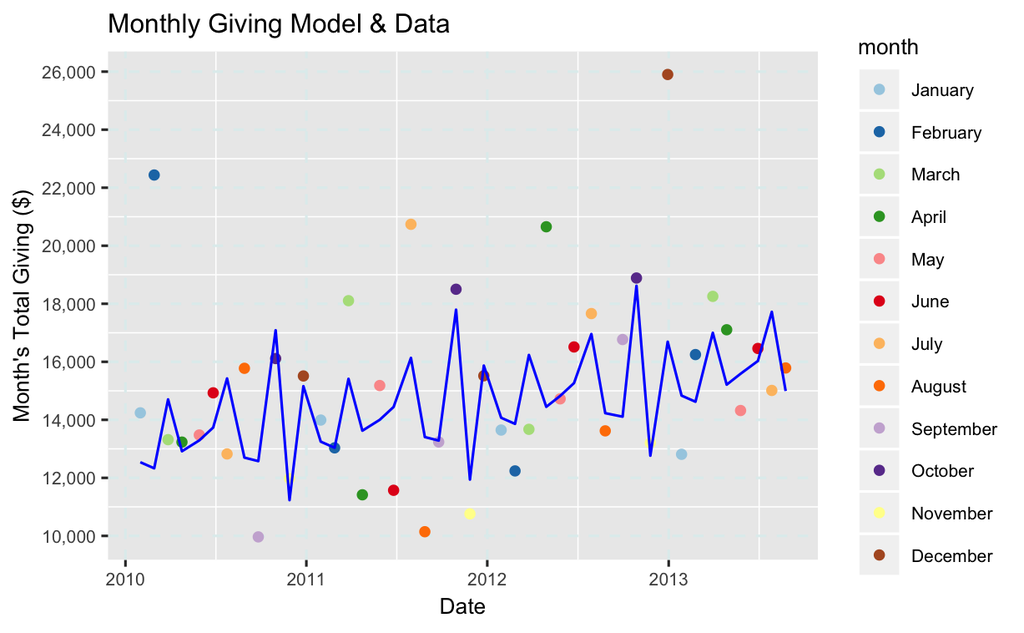

```
Analysis of Variance Table

Response: total
          Df    Sum Sq Mean Sq F value Pr(>F)
year       3  21431854 7143951  1.4506  0.251
month     11  93473089 8497554  1.7254  0.123
Residuals 26 128049780 4924992
```

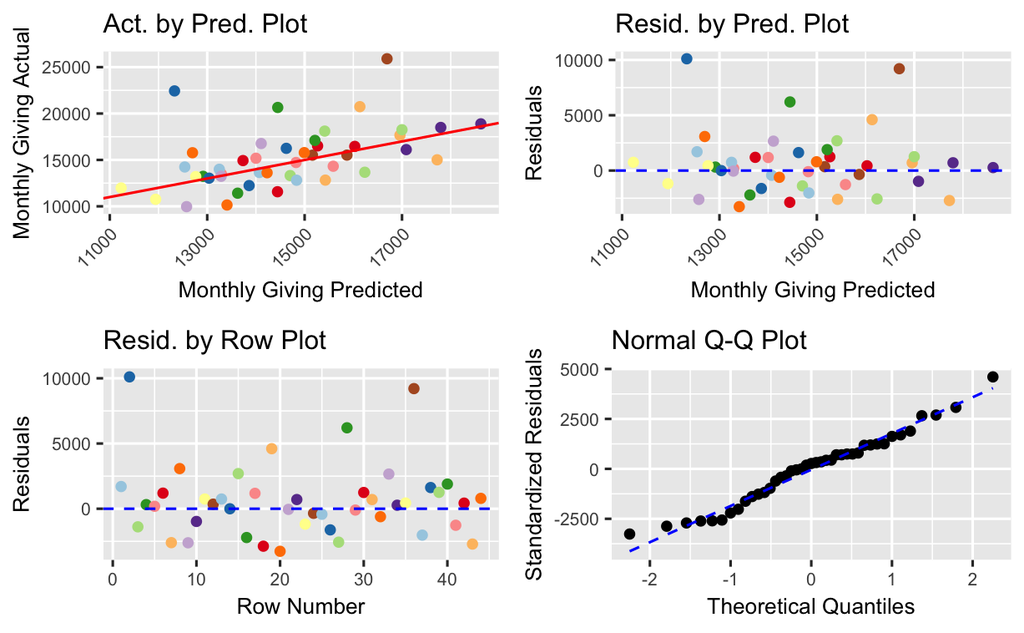

```
Call:
lm(formula = total ~ year + month, data = df2[df2$excluded !=
    TRUE, ])

Residuals:
    Min      1Q  Median      3Q     Max
-3262.7 -1266.4   269.4  1181.2  4604.5

Coefficients:
               Estimate Std. Error t value Pr(>|t|)
(Intercept)    12539.40    1264.30   9.918 2.52e-10 ***
year2011         708.72     933.26   0.759   0.4544
year2012        1531.73     997.47   1.536   0.1367
year2013        2295.36    1082.20   2.121   0.0436 *
monthFebruary   -210.59    1706.96  -0.123   0.9028
monthMarch      2164.52    1569.23   1.379   0.1795
monthApril       376.99    1707.70   0.221   0.8270
monthMay         752.68    1569.23   0.480   0.6355
monthJune       1195.27    1569.23   0.762   0.4531
monthJuly       2886.33    1569.23   1.839   0.0773 .
monthAugust      158.54    1569.23   0.101   0.9203
monthSeptember    37.28    1710.48   0.022   0.9828
monthOctober    4547.45    1710.48   2.659   0.0132 *
monthNovember  -1306.57    1710.48  -0.764   0.4518
monthDecember   2621.14    1956.39   1.340   0.1919
---
Signif. codes:  0 ‘***’ 0.001 ‘**’ 0.01 ‘*’ 0.05 ‘.’ 0.1 ‘ ’ 1

Residual standard error: 2219 on 26 degrees of freedom
Multiple R-squared:  0.4729,    Adjusted R-squared:  0.1892
F-statistic: 1.666 on 14 and 26 DF,  p-value: 0.1261
```

The results obtained are different in a number of ways from what was obtained in 2013. The general fit (residuals) and shape of the predicted values are similar to that obtained in 2013 though the June predictions seem further away than the other months. The regressed coefficients are obviously very different (See Model Generalization below), but this is largely due to the method JMP uses for regressing factor coefficients. However, the difference in the June predictions and slightly different factor p-values tells me that something in the underlying data is probably different. I’m not going to spend the time to diagnose the precise details of the difference since the objective is to translate the analysis to R rather than reproduce JMP.

# Model Generalization

Due to R’s conventions, the model coefficients, as regressed by R:
$$\textit{Monthly Giving} = a+b_{year}+c_{month}$$
are regressed relative to $month_1$=January ($c_{January}=0$) and $year_1$=2010 ($b_{2010}=0$). This is why there is no year2010 nor monthJanuary coeffiencients. A more useful set of references for forecasting would be “an average month” and “an average year”. Thus we can modify the model as such:
$$\begin{aligned}
\begin{split}
\textit{Monthly Giving}
&= a+(\overline{b_{year}}+b_{year}-\overline{b_{year}})+
(\overline{c_{month}}+c_{month}-\overline{c_{month}})
\\
&= \big[a+\overline{b_{year}}+\overline{c_{month}}\big]+
\big(b_{year}-\overline{b_{year}}\big)+
\big(c_{month}-\overline{c_{month}}\big)
\end{split}
\end{aligned}$$
where $\overline{b_{year}}$ is the mean of $b_{year}$ coefficients, including $b_{2010}=0$, and $\overline{c_{month}}$ is the mean of the $c_{year}$ coefficients, including $c_{January}=0$. The term $\big[a+\overline{b_{year}}+\overline{c_{month}}\big]$ is then the regressed $\textit{Monthly Giving}$ for an average month in an average year over the period covered by the data. Of course no actual month or year is the average, and to reproduce a given month and year prediction the shifted coefficients $(b_{year}-\overline{b_{year}}) \text{ and } (c_{month}-\overline{c_{month}})$ must be employed. However, this facilitates using the model for monthly variance predictions in the upcoming year since:
$$\begin{aligned}
\begin{split}
\textit{Average Monthly Giving}_\textit{next year}
&=\big[a+\overline{b_{year}}+\overline{c_{month}}\big]+\big(b_\textit{next year}-\overline{b_{year}}\big)
\\
&=\frac{\textit{Projected Income}_\textit{next year}}{12}
\end{split}
\end{aligned}$$
So even though we don’t know $b_\textit{next year}$ we can make an estimation for next year’s total $\textit{Projected Income}$ and get monthly estimates based on the annual estimate:

$$\textit{Monthly Giving}_\textit{next year}
=\frac{\textit{Projected Income}_\textit{next year}}{12} +
\big(c_{month}-\overline{c_{month}}\big)$$

# Monthly Variation

This plot shows the resulting $month$ regression coeffiecients shifted by $\overline{c_{month}}$ capturing month-to-month variation. ($(c_{month}-\overline{c_{month}})$) The shape of the yearly repeated pattern in the prediction are the result of these terms.

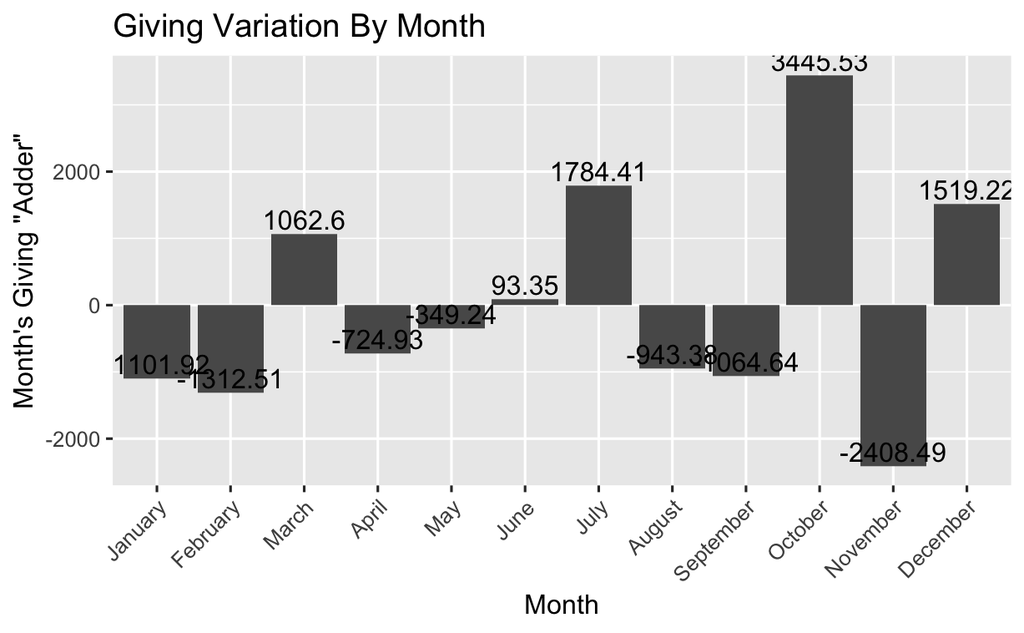

These values are much closer to those regressed in 2013 by JMP.

# References

Davern, Sean. 2013. “An Assessment of Requested Seed Core Support for Expansion Based on Analysis of Giving.” *Internal Report*, August. file://../Reports/August%202013%20Analysis%20of%20Giving.pdf.